# rgplates

[figure not shown]

[figure not shown]

R interface for the GPlates Web Service and Desktop Application

See the webpage of the package for more info and tutorials: https://gplates.github.io/rgplates/

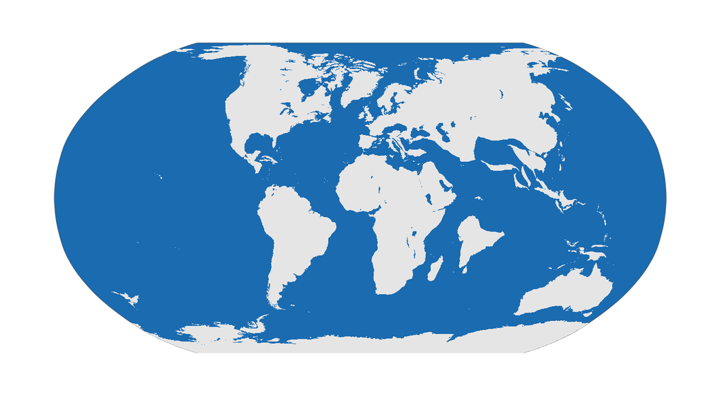

(Ádám T. Kocsis, Nussaïbah B. Raja, Simon Williams and Elizabeth M. Dowding) Query functions to the GPlates https://www.gplates.org/ Desktop Application and the GPlates Web Service https://gws.gplates.org/ allow users to reconstruct past positions of geographic entities based on user-selected rotation models without leaving the R running environment. The online method (GPlates Web Service) makes the rotation of static plates, coastlines, and a low number of geographic coordinates available using nothing but an internet connection. The offline method requires an external installation of the GPlates Desktop Application, but allows the efficient batch rotation of thousands of coordinates, Simple Features (sf) and Spatial (sp) objects with custom reconstruction trees and partitioning polygons. Examples of such plate tectonic models are accessible via the chronosphere-portal https://cran.r-project.org/package=chronosphere. This R extension is developed under the umbrella of the DFG (Deutsche Forschungsgemeinschaft) Research Unit TERSANE2 (For 2332, TEmperature Related Stressors in ANcient Extinctions).

The functions here were removed from the chronosphere R package (v0.4.1), for better compliance with UNIX-principles and more efficient distribution/development.

This is a beta version.